# Testing some models for seal data

Author

Max Lindmark & Monica Mion

Published

February 18, 2026

```r
library(ggplot2); theme_set(theme_light())
library(stringr)
library(tidyr)
library(dplyr)
library(tidylog)
library(ggeffects)
library(sdmTMB)
library(modelr)
library(readr)

home <- here::here()
```

Read data

```r
d <- read_csv(paste0(home, "/data/HS_SKAG_matrix_biomass_abundance.csv")) |>
  janitor::clean_names() |>
  rename(pw = sum_biomass_not_corrected_g) |>
  mutate(family = as.factor(family),
         year_f = as.factor(year),
         year_ct = year - min(year),
         month_f = as.factor(month))
```

Now expand the data so that every predator has one row for each prey type (currently no zeroes-by-prey group)

```r
# Expand the data
d <- d |>
  group_by(sample_id) |>
  complete(
    family,
    fill = list(
      pw = 0,
      sum_abundance = 0
    )
  ) |>
  fill(lat, lon, year, month, quarter, year_f, year_ct, month_f,
       .direction = "downup") |>
  ungroup()

# Check if we need to summarise prey weight a bit more
d |>
  summarise(sum_pw = sum(pw), .by = family) |>
  mutate(percent = (sum_pw / sum(sum_pw)) * 100) |>
  arrange(desc(percent))
```

```
# A tibble: 16 × 3
   family             sum_pw   percent
   <fct>               <dbl>     <dbl>
 1 Gadidae        136740.    54.7
 2 Clupeidae       44854.    17.9
 3 Scophthalmidae  27667.    11.1
 4 Pleuronectidae  11407.     4.56
 5 Gobiidae         9948.     3.98
 6 Belonidae        6980.     2.79
 7 Anguillidae      4237.     1.69
 8 Zoarcidae        4177.     1.67
 9 Scombridae       2121.     0.848
10 Labridae         1161.     0.465
11 Salmonidae        473.     0.189
12 Soleidae          179.     0.0715
13 Bothidae           44.0    0.0176
14 Merlucciidae       19.5    0.00778
15 Osmeridae           1.79   0.000716
16 Gasterosteidae      0.488  0.000195
```

```r
# Group all prey below 3% into "other"
d <- d |>
  mutate(percent = 100 * sum(pw) / sum(d$pw), .by = family) |>
  mutate(family = if_else(percent < 3,
                          "Other",
                          as.character(family))) |>
  select(-percent) |>
  summarise(
    pw = sum(pw),
    sum_abundance = sum(sum_abundance),
    .by = c(sample_id, family, lat, lon, year,
            month, quarter, year_f, year_ct, month_f)
  )
```

Explore the data quickly

```r
head(d)
```

```
# A tibble: 6 × 12
  sample_id family   lat   lon  year month quarter year_f year_ct month_f     pw
  <chr>     <chr>  <dbl> <dbl> <dbl> <dbl>   <dbl> <fct>    <dbl> <fct>    <dbl>
1 A2012/05… Other   58.6  11.2  2011    12       4 2011         0 12      0
2 A2012/05… Clupe…  58.6  11.2  2011    12       4 2011         0 12      0
3 A2012/05… Gadid…  58.6  11.2  2011    12       4 2011         0 12      1.11e3
4 A2012/05… Gobii…  58.6  11.2  2011    12       4 2011         0 12      6.89e0
5 A2012/05… Pleur…  58.6  11.2  2011    12       4 2011         0 12      2.74e0
6 A2012/05… Scoph…  58.6  11.2  2011    12       4 2011         0 12      0
# ℹ 1 more variable: sum_abundance <dbl>
```

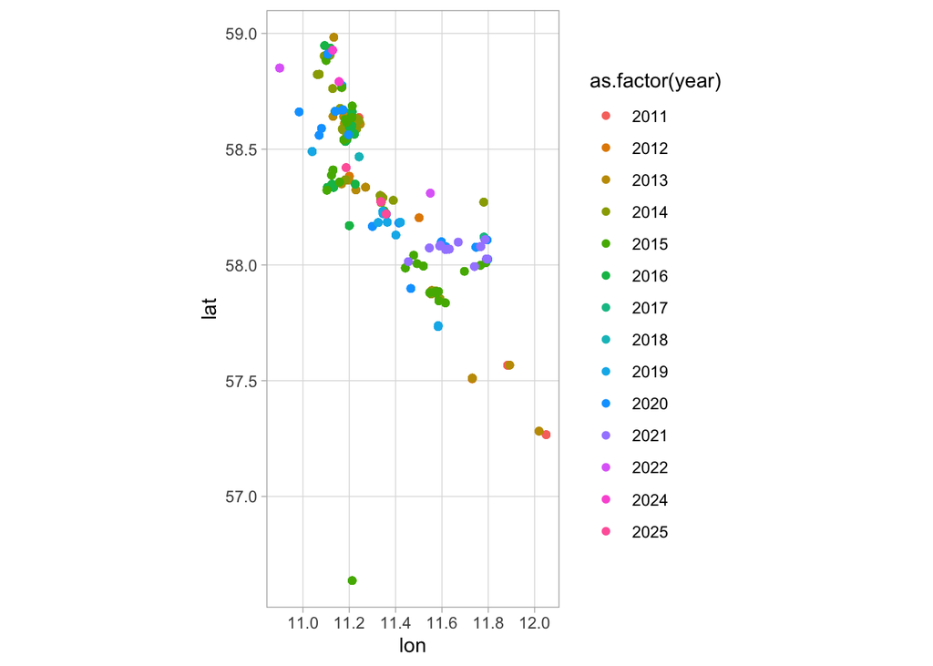

```r
ggplot(d, aes(lon, lat, color = as.factor(year))) +
  geom_point() +
  coord_sf()
```

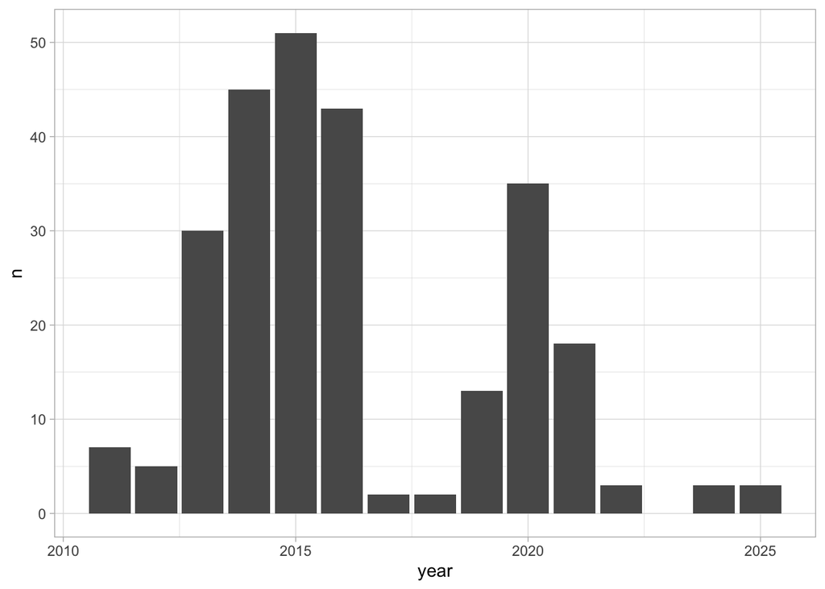

```r
d |>
  summarise(n = n_distinct(sample_id), .by = year) |>
  ggplot(aes(year, n)) +
  geom_bar(stat = "identity")
```

```r
summary(d$pw)
```

```
    Min.  1st Qu.   Median     Mean  3rd Qu.     Max.
    0.00     0.00     0.00   160.26    20.07 20820.92
```

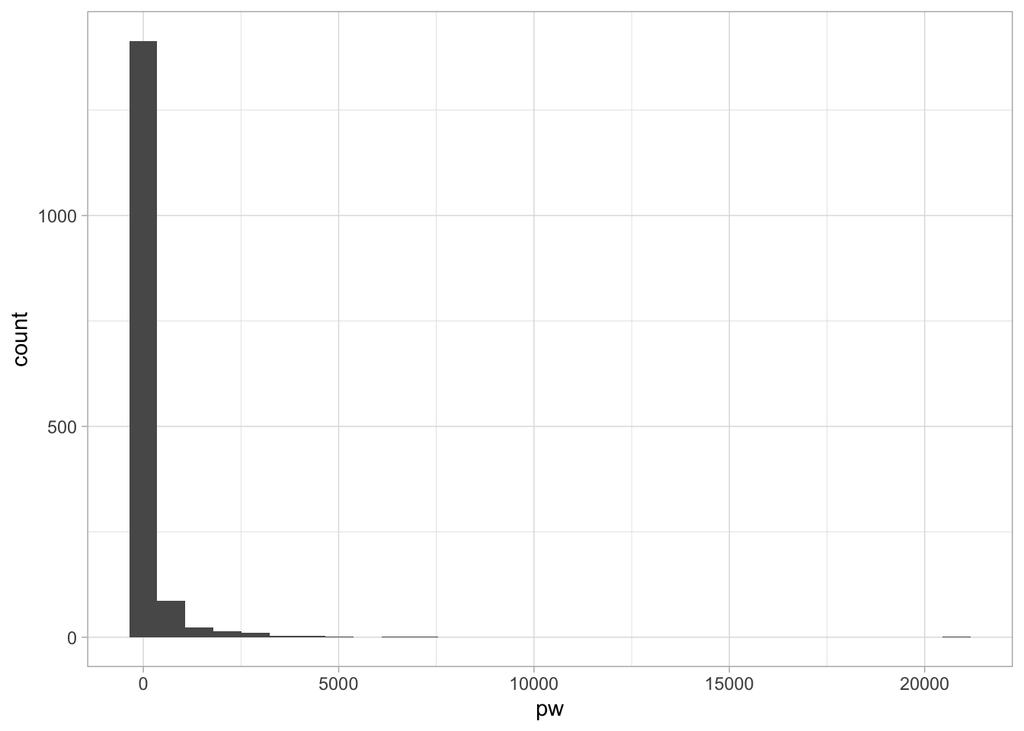

```r
ggplot(d, aes(pw)) +
  geom_histogram()
```

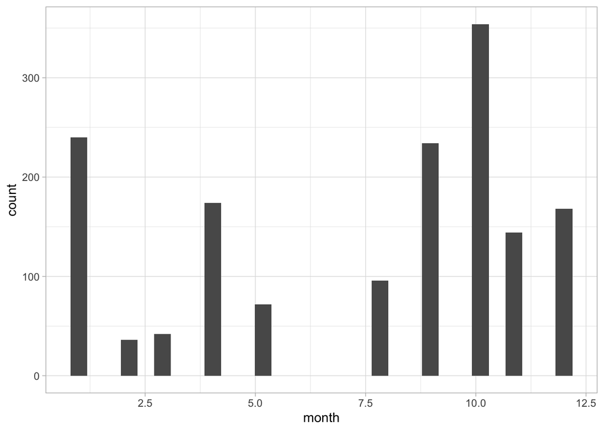

```r
ggplot(d, aes(month)) +
  geom_histogram()
```

Fit a simple model, estimating the mean prey weight by family, ignoring space and time

```r
# Fit a simple model
# Let's use a delta_gamma model to have a bit more flexibility than a tweedie
m1 <- sdmTMB(
  pw ~ 0 + family,
  data = d,
  family = delta_gamma(type = "poisson-link"),
  spatial = "off"
)

summary(m1)
```

```
Model fit by ML ['sdmTMB']
Formula: pw ~ 0 + family
Mesh:  (isotropic covariance)
Data: d
Family: delta_gamma(link1 = 'log', link2 = 'log', type = 'poisson-link')

Delta/hurdle model 1: -----------------------------------
Family: binomial(link = 'log')
Conditional model:
                     coef.est coef.se
familyClupeidae         -0.01    0.08
familyGadidae            0.38    0.08
familyGobiidae          -1.00    0.11
familyOther             -2.13    0.19
familyPleuronectidae    -1.76    0.16
familyScophthalmidae    -4.46    0.58


Delta/hurdle model 2: -----------------------------------
Family: Gamma(link = 'log')
Conditional model:
                     coef.est coef.se
familyClupeidae          5.16    0.12
familyGadidae            5.88    0.12
familyGobiidae           4.64    0.17
familyOther              6.45    0.28
familyPleuronectidae     5.54    0.24
familyScophthalmidae     9.12    0.88

Dispersion parameter: 0.43

ML criterion at convergence: 4087.404

See ?tidy.sdmTMB to extract these values as a data frame.
```

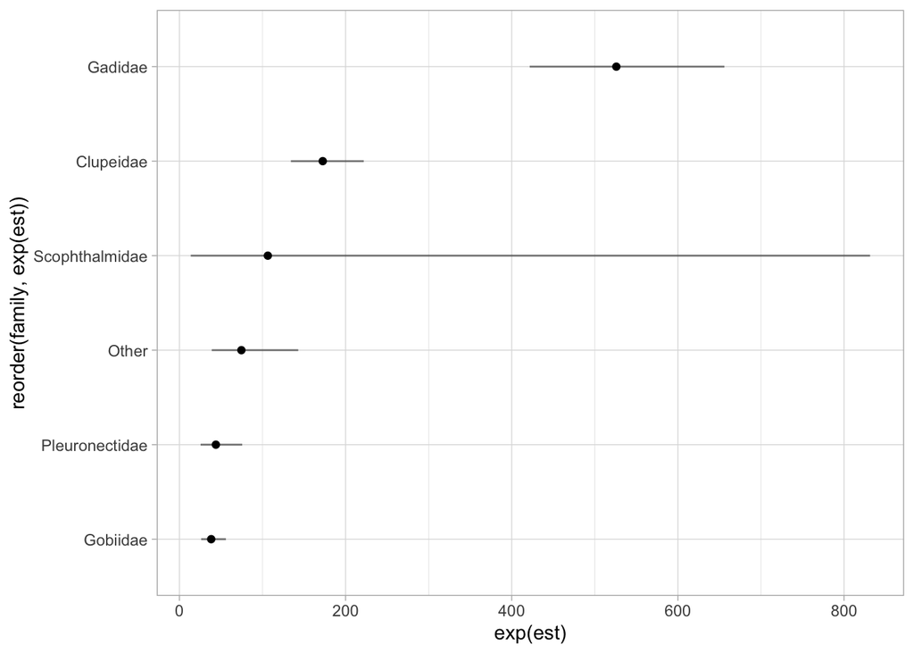

```r
nd <- d |>
  distinct(family)

# est here is the combined prediction from the binomial and the gamma model
# It's the same as est1 + est2. This is one of the reasons we use a type = "poisson-link",
# because in standard delta models the two sub models have different link functions and thereby
# cannot be added
p <- predict(m1, newdata = nd, se_fit = TRUE) |>
  mutate(upr = est + 1.96*est_se,
         lwr = est - 1.96*est_se)

ggplot(p, aes(exp(est), reorder(family, exp(est)))) +
  geom_point() +
  geom_errorbar(aes(xmin = exp(lwr), xmax = exp(upr)),
                width = 0, alpha = 0.5)
```

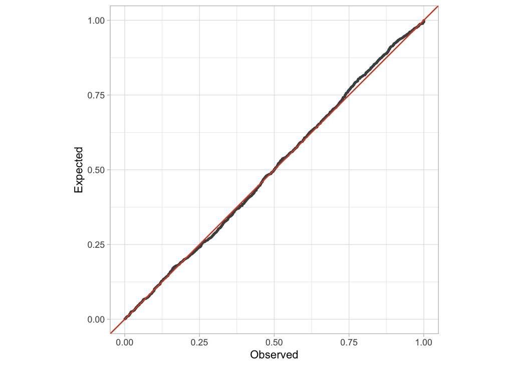

```r
# Check residuals of the combined model (both components). We do this with dharma
res <- simulate(m1, nsim = 300, type = "mle-mvn") |>
  dharma_residuals(m1, plot = FALSE)

# Plot residuals
res |>
  ggplot(aes(observed, expected)) +
  geom_point(color = "grey30", shape = 21, size = 0.5) +
  geom_abline(col = "tomato3", linewidth = 0.6) +
  theme(aspect.ratio = 1) +
  labs(x = "Observed", y = "Expected")
```

```r
# It looks slightly better if you remove the uncommon families
```

Now add year to the model. There are many options for how. We’ll look into a factor year, linear year and autoregressive year effects.

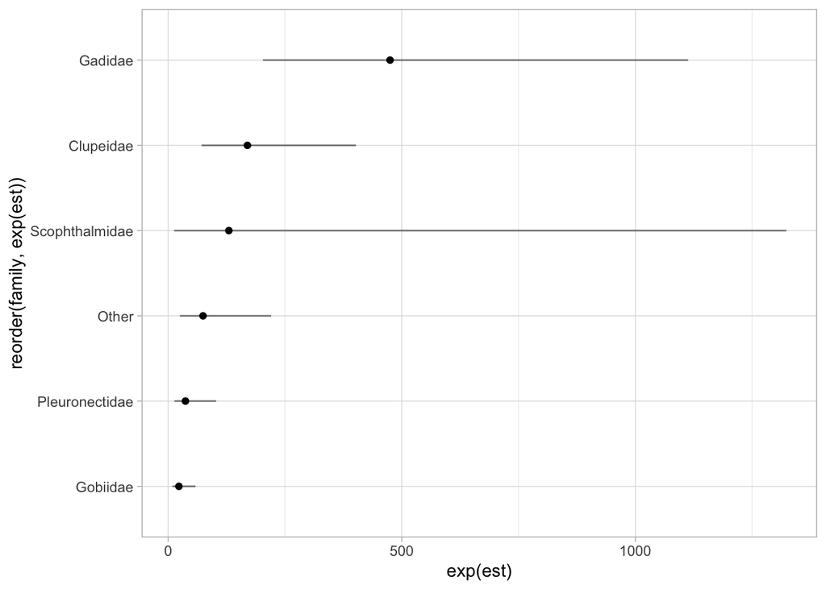

```r
m2 <- sdmTMB(
  pw ~ 0 + family + year_f,
  data = d,
  family = delta_gamma(type = "poisson-link"),
  spatial = "off"
)

nd2 <- d |>
  distinct(family, year_f)

p2 <- predict(m2, newdata = nd2, se_fit = TRUE) |>
  mutate(upr = est + 1.96*est_se,
         lwr = est - 1.96*est_se,
         year = as.numeric(as.character(year_f)))

p2 |>
  summarise(est = mean(est),
            upr = mean(upr),
            lwr = mean(lwr), .by = family) |>
  ggplot(aes(exp(est), reorder(family, exp(est)))) +
  geom_point() +
  geom_errorbar(aes(xmin = exp(lwr), xmax = exp(upr)),
                width = 0, alpha = 0.5)
```

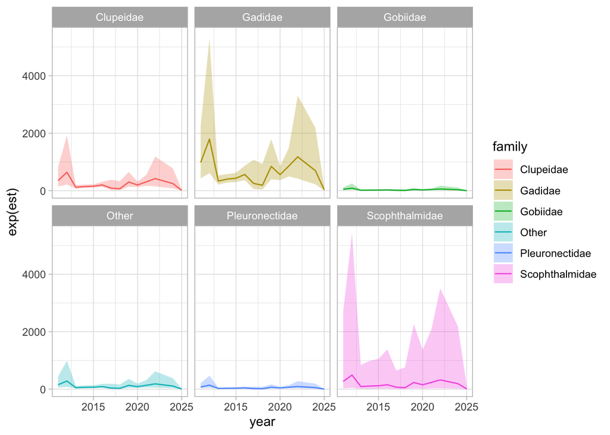

```r
# Now plot the year-prediction
p2 |>
  ggplot(aes(year, exp(est), color = family, fill = family)) +
  geom_line() +
  geom_ribbon(aes(ymin = exp(lwr), ymax = exp(upr)),
              alpha = 0.3, color = NA) +
  facet_wrap(~family)
```

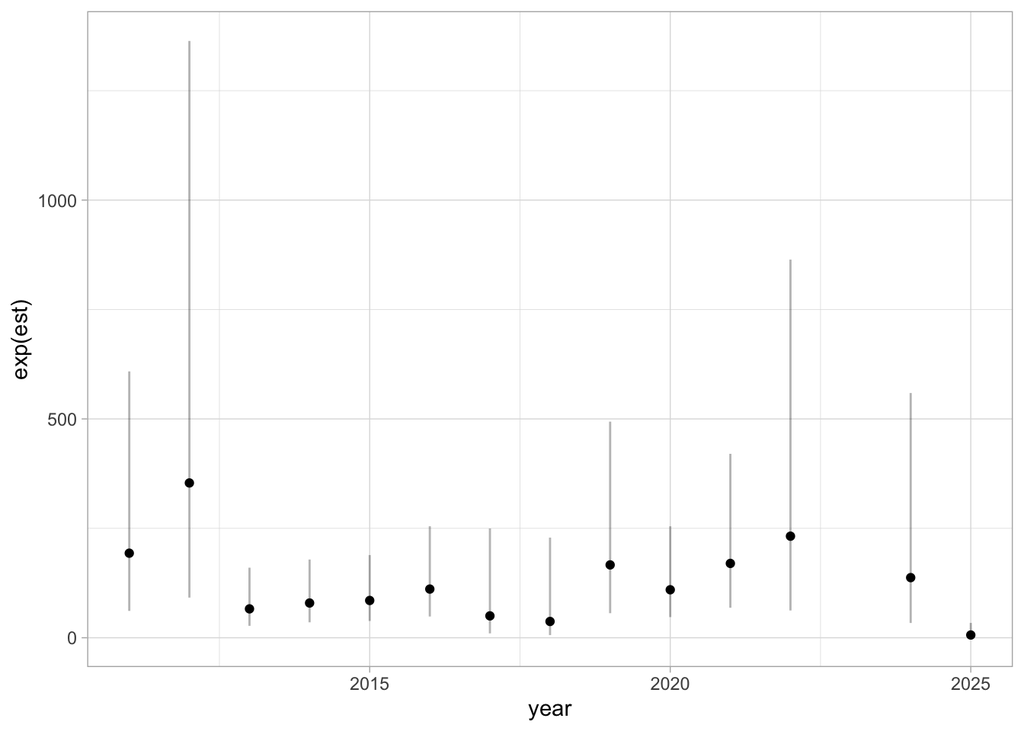

```r
# And now the total prey weight over time
p2 |>
  summarise(est = mean(est),
            upr = mean(upr),
            lwr = mean(lwr), .by = year) |>
  ggplot(aes(year, exp(est))) +
  geom_point() +
  geom_errorbar(aes(ymin = exp(lwr), ymax = exp(upr)),
                alpha = 0.3, width = 0)
```

Linear year effect

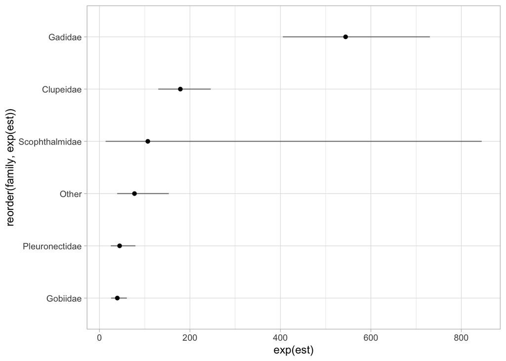

```r
m3 <- sdmTMB(
  pw ~ family + year_ct, # use centered year to aid convergence
  data = d,
  family = delta_gamma(type = "poisson-link"),
  spatial = "off"
)

nd3 <- d |>
  distinct(family, year_ct, year)

p3 <- predict(m3, newdata = nd3, se_fit = TRUE) |>
  mutate(upr = est + 1.96*est_se,
         lwr = est - 1.96*est_se)

p3 |>
  summarise(est = mean(est),
            upr = mean(upr),
            lwr = mean(lwr), .by = family) |>
  ggplot(aes(exp(est), reorder(family, exp(est)))) +
  geom_point() +
  geom_errorbar(aes(xmin = exp(lwr), xmax = exp(upr)),
                width = 0, alpha = 0.5)
```

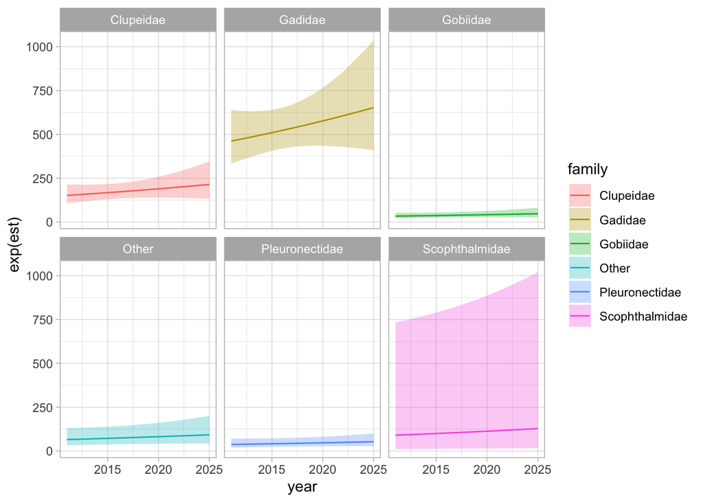

```r
# Now plot the year-prediction
p3 |>
  ggplot(aes(year, exp(est), color = family, fill = family)) +
  geom_line() +
  geom_ribbon(aes(ymin = exp(lwr), ymax = exp(upr)),
              alpha = 0.3, color = NA) +
  facet_wrap(~family)
```

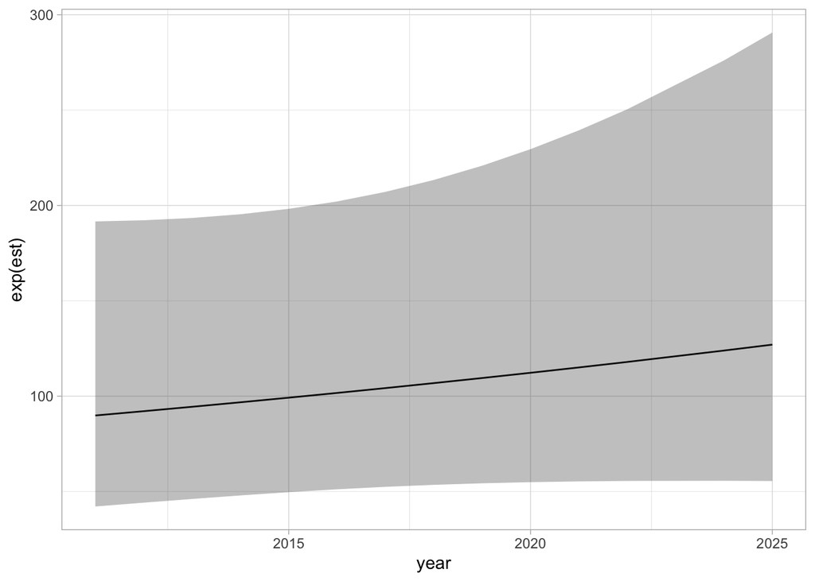

```r
# And now the total prey weight over time
p3 |>
  summarise(est = mean(est),
            upr = mean(upr),
            lwr = mean(lwr), .by = year) |>
  ggplot(aes(year, exp(est))) +
  geom_line() +
  geom_ribbon(aes(ymin = exp(lwr), ymax = exp(upr)),
              alpha = 0.3, color = NA)
```

Linear year effect but different slopes for each family

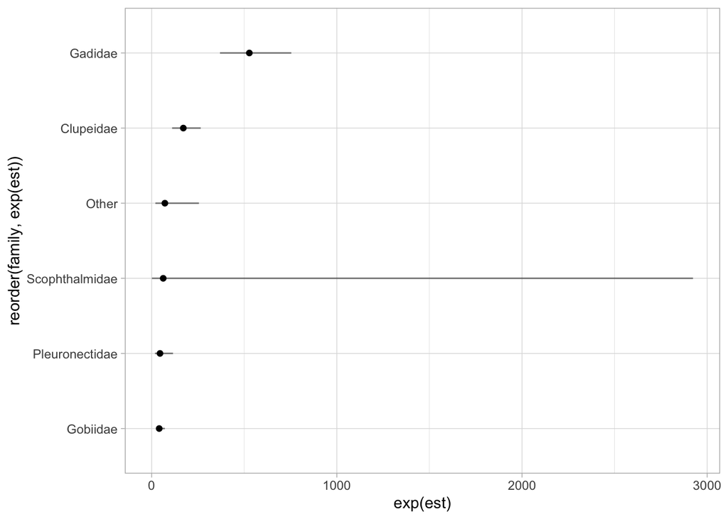

```r
m4 <- sdmTMB(
  pw ~ family*year_ct, # use centered year to aid convergence
  data = d,
  family = delta_gamma(type = "poisson-link"),
  spatial = "off"
)

nd4 <- d |>
  distinct(family, year_ct, year)

p4 <- predict(m4, newdata = nd4, se_fit = TRUE) |>
  mutate(upr = est + 1.96*est_se,
         lwr = est - 1.96*est_se)

# TODO: Based on the exploded uncertainty here, I would maybe play around with adding priors on the fixed effects...
p4 |>
  summarise(est = mean(est),
            upr = mean(upr),
            lwr = mean(lwr), .by = family) |>
  ggplot(aes(exp(est), reorder(family, exp(est)))) +
  geom_point() +
  geom_errorbar(aes(xmin = exp(lwr), xmax = exp(upr)),
                width = 0, alpha = 0.5)
```

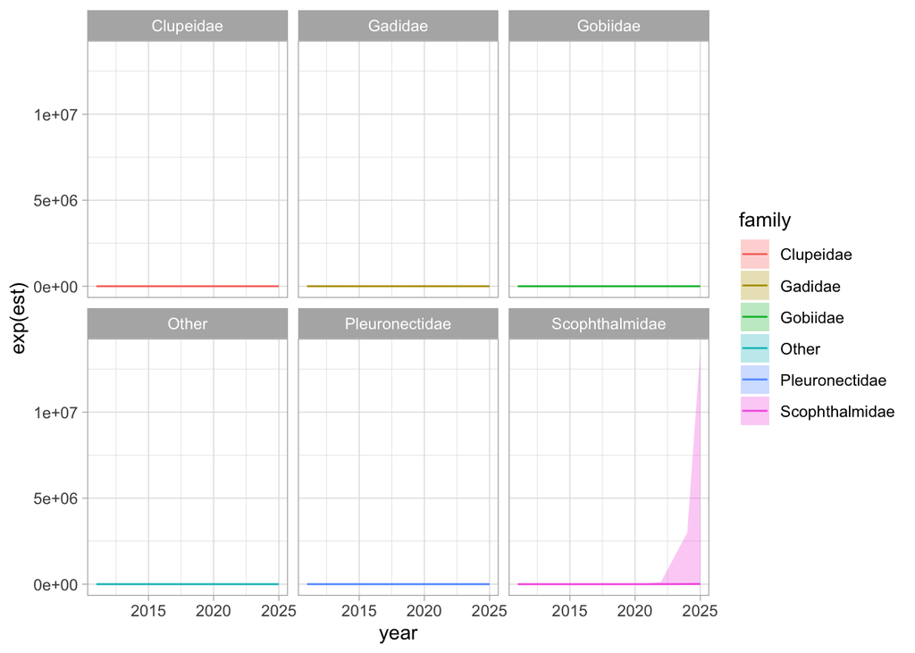

```r
# Now plot the year-prediction
p4 |>
  ggplot(aes(year, exp(est), color = family, fill = family)) +
  geom_line() +
  geom_ribbon(aes(ymin = exp(lwr), ymax = exp(upr)),
              alpha = 0.3, color = NA) +
  facet_wrap(~family)
```

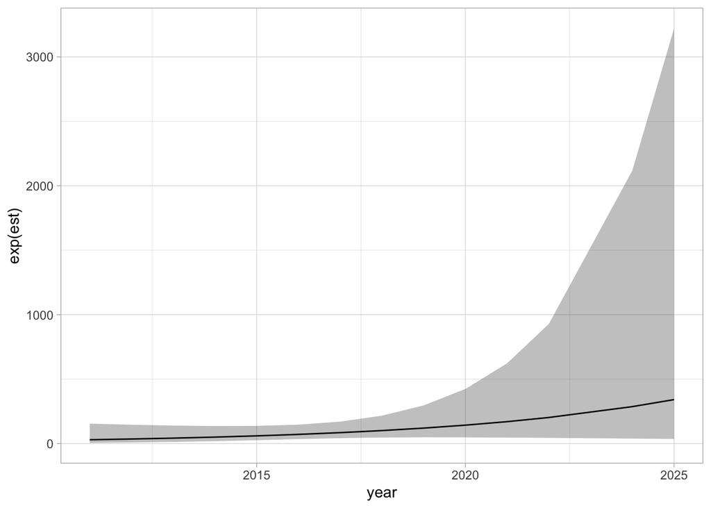

```r
# And now the total prey weight over time
p4 |>
  summarise(est = mean(est),
            upr = mean(upr),
            lwr = mean(lwr), .by = year) |>
  ggplot(aes(year, exp(est))) +
  geom_line() +
  geom_ribbon(aes(ymin = exp(lwr), ymax = exp(upr)),
              alpha = 0.3, color = NA)
```

The interaction above explodes for some families..

What if we wanted to model time for as a time series, using an autoregressive approach?

```r
m5 <- sdmTMB(
  pw ~ 1 + family,
  data = d,
  time_varying = ~1,
  # TODO: we could also do a random walk, but ar1 seems easier to converge. basically: do we want the trend to be able to drift off
  # (only year before matters), or do we want the annual values to revert to mean in absence of data?
  time_varying_type = "ar1",
  # now that we are modelling a process over time, we need to specify any missing years we want to predict over, using process error only
  extra_time = 2023,
  # we also need to define which is our time-column, now that we have a temporal model
  time = "year",
  family = delta_gamma(type = "poisson-link"),
  # when we add a time-component, the default is to add a spatiotemporal field. We turn this off for now!
  spatial = "off",
  spatiotemporal = "off"
)

summary(m5)
```

```
Model fit by ML ['sdmTMB']
Formula: pw ~ 1 + family
Mesh:  (isotropic covariance)
Time column: character
Data: d
Family: delta_gamma(link1 = 'log', link2 = 'log', type = 'poisson-link')

Delta/hurdle model 1: -----------------------------------
Family: binomial(link = 'log')
Conditional model:
                     coef.est coef.se
(Intercept)             -0.01    0.09
familyGadidae            0.40    0.11
familyGobiidae          -0.98    0.14
familyOther             -2.12    0.20
familyPleuronectidae    -1.75    0.18
familyScophthalmidae    -4.44    0.58

Time-varying parameters:
                 coef.est coef.se
(Intercept)-2011     0.01    0.08
(Intercept)-2012     0.01    0.06
(Intercept)-2013    -0.03    0.12
(Intercept)-2014     0.01    0.06
(Intercept)-2015     0.01    0.06
(Intercept)-2016    -0.04    0.13
(Intercept)-2017     0.01    0.07
(Intercept)-2018     0.00    0.06
(Intercept)-2019    -0.02    0.10
(Intercept)-2020     0.00    0.06
(Intercept)-2021     0.04    0.14
(Intercept)-2022     0.02    0.10
(Intercept)-2023     0.00    0.06
(Intercept)-2024     0.01    0.07
(Intercept)-2025    -0.01    0.06
rho-(Intercept)     -0.06    1.00


Delta/hurdle model 2: -----------------------------------
Family: Gamma(link = 'log')
```

[output cut: 18 more lines]

```
(Intercept)-2018    -0.05    0.27
(Intercept)-2019     0.23    0.25
(Intercept)-2020     0.02    0.18
(Intercept)-2021     0.06    0.19
(Intercept)-2022     0.08    0.23
(Intercept)-2023     0.01    0.25
(Intercept)-2024    -0.03    0.23
(Intercept)-2025    -0.12    0.28
rho-(Intercept)      0.12    0.50

Dispersion parameter: 0.44

ML criterion at convergence: 4086.249

See ?tidy.sdmTMB to extract these values as a data frame.
```

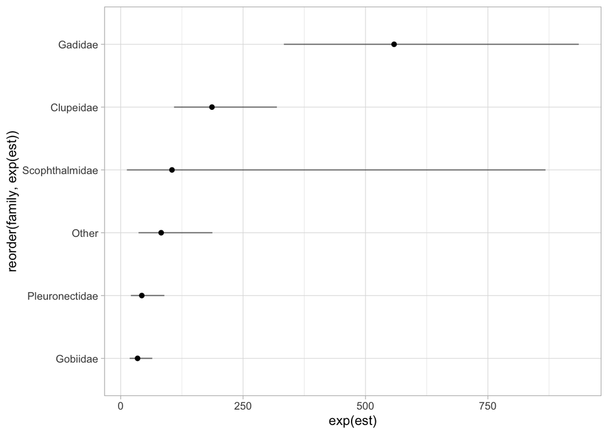

```r
sanity(m5)

nd5 <- d |>
  distinct(family, year) |>
  # add the missing year, 2023!
  bind_rows(d |>
              distinct(family) |>
              mutate(year = 2023))

p5 <- predict(m5, newdata = nd5, se_fit = TRUE) |>
  mutate(upr = est + 1.96*est_se,
         lwr = est - 1.96*est_se)

p5 |>
  summarise(est = mean(est),
            upr = mean(upr),
            lwr = mean(lwr), .by = family) |>
  ggplot(aes(exp(est), reorder(family, exp(est)))) +
  geom_point() +
  geom_errorbar(aes(xmin = exp(lwr), xmax = exp(upr)),
                width = 0, alpha = 0.5)
```

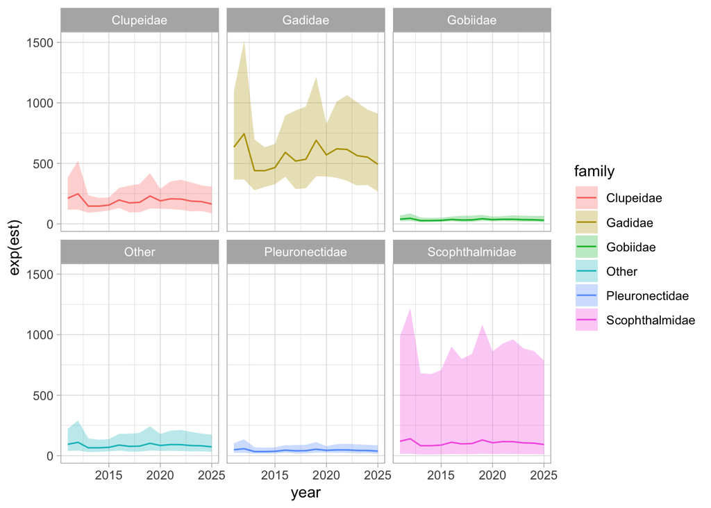

```r
# Now plot the year-prediction
p5 |>
  ggplot(aes(year, exp(est), color = family, fill = family)) +
  geom_line() +
  geom_ribbon(aes(ymin = exp(lwr), ymax = exp(upr)),
              alpha = 0.3, color = NA) +
  facet_wrap(~family)
```

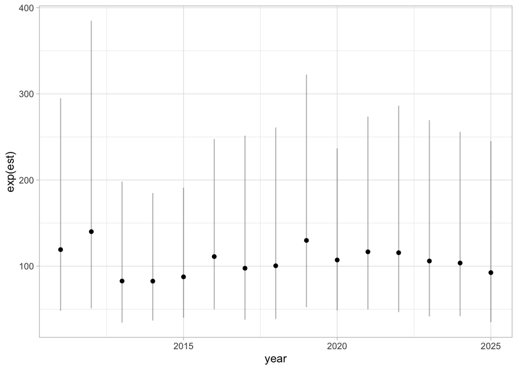

```r
# And now the total prey weight over time
# Note how we get an estimate for 2023 now!
p5 |>
  summarise(est = mean(est),
            upr = mean(upr),
            lwr = mean(lwr), .by = year) |>
  ggplot(aes(year, exp(est))) +
  geom_point() +
  geom_errorbar(aes(ymin = exp(lwr), ymax = exp(upr)),
                alpha = 0.3, width = NA)
```

```r
AIC(m1, m2, m3, m4, m5) |>
  arrange(AIC)
```

```
   df      AIC
m2 39 8199.383
m1 13 8200.808
m3 15 8203.117
m4 25 8206.474
m5 17 8206.497
```

Now testing adding spatial random effects

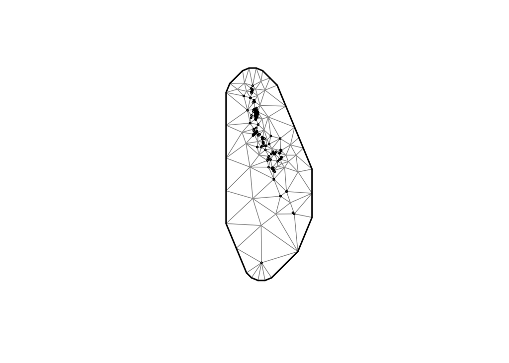

```r
d <- d |>
  add_utm_columns(ll_names = c("lon", "lat"))

mesh <- make_mesh(d, xy_cols = c("X", "Y"), type = "cutoff", cutoff = 4)

plot(mesh)
```

```r
mesh$mesh$n
```

```
[1] 100
```

```r
m6 <- sdmTMB(
  pw ~ 0 + family + year_f,
  data = d,
  mesh = mesh,
  family = delta_gamma(type = "poisson-link"),
  # TODO: this can be explored a bit. From experience and from testing with this data a bit,
  # it's much easier to estimate the binomial part (including any random effects), compared to the positive biomass part
  # Hence I estimate here only a spatial random effect for the binomial part.
  spatial = list("on", "off"),
  # priors = sdmTMBpriors(
  #   matern_s = pc_matern(range_gt = 5, sigma_lt = 1)
  #   )
)

summary(m6)
```

```
Spatial model fit by ML ['sdmTMB']
Formula: pw ~ 0 + family + year_f
Mesh: mesh (isotropic covariance)
Data: d
Family: delta_gamma(link1 = 'log', link2 = 'log', type = 'poisson-link')

Delta/hurdle model 1: -----------------------------------
Family: binomial(link = 'log')
Conditional model:
                     coef.est coef.se
familyClupeidae          0.18    0.29
familyGadidae            0.62    0.29
familyGobiidae          -0.78    0.30
familyOther             -1.94    0.33
familyPleuronectidae    -1.56    0.32
familyScophthalmidae    -4.27    0.64
year_f2012              -0.24    0.44
year_f2013              -0.38    0.31
year_f2014              -0.09    0.30
year_f2015              -0.10    0.31
year_f2016              -0.37    0.31
year_f2017               0.15    0.55
year_f2018              -0.22    0.62
year_f2019              -0.55    0.37
year_f2020              -0.26    0.31
year_f2021              -0.01    0.35
year_f2022               0.72    0.51
year_f2024               0.24    0.49
year_f2025              -0.39    0.55

Matérn range: 9.14
Spatial SD: 0.22

Delta/hurdle model 2: -----------------------------------
Family: Gamma(link = 'log')
Conditional model:
                     coef.est coef.se
familyClupeidae          5.66    0.43
familyGadidae            6.24    0.41
familyGobiidae           4.62    0.40
familyOther              6.96    0.50
familyPleuronectidae     5.88    0.48
familyScophthalmidae     9.84    1.02
year_f2012               0.86    0.62
year_f2013              -0.67    0.46
year_f2014              -0.75    0.44
year_f2015              -0.64    0.44
year_f2016              -0.14    0.44
year_f2017              -1.53    0.79
year_f2018              -1.39    0.87
year_f2019               0.47    0.52
year_f2020              -0.32    0.45
year_f2021              -0.20    0.45
year_f2022              -0.53    0.70
year_f2024              -0.61    0.68
year_f2025              -3.02    0.81

Dispersion parameter: 0.45

ML criterion at convergence: 4059.582

See ?tidy.sdmTMB to extract these values as a data frame.
```

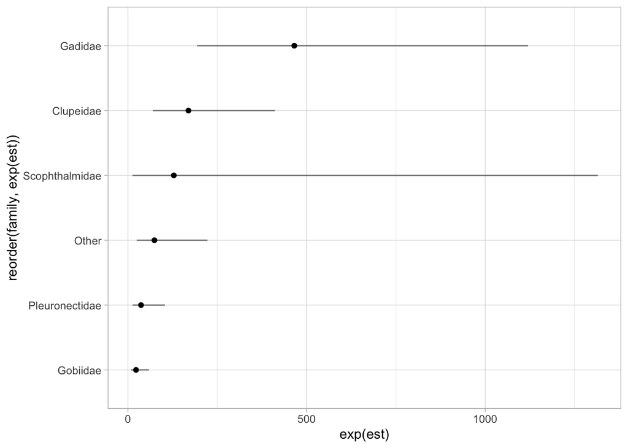

```r
sanity(m6)

nd6 <- d |>
  distinct(family, year, year_f)

p6 <- predict(m6, newdata = nd6, se_fit = TRUE, re_form = NA) |>
  mutate(upr = est + 1.96*est_se,
         lwr = est - 1.96*est_se)

p6 |>
  summarise(est = mean(est),
            upr = mean(upr),
            lwr = mean(lwr), .by = family) |>
  ggplot(aes(exp(est), reorder(family, exp(est)))) +
  geom_point() +
  geom_errorbar(aes(xmin = exp(lwr), xmax = exp(upr)),
                width = 0, alpha = 0.5)
```

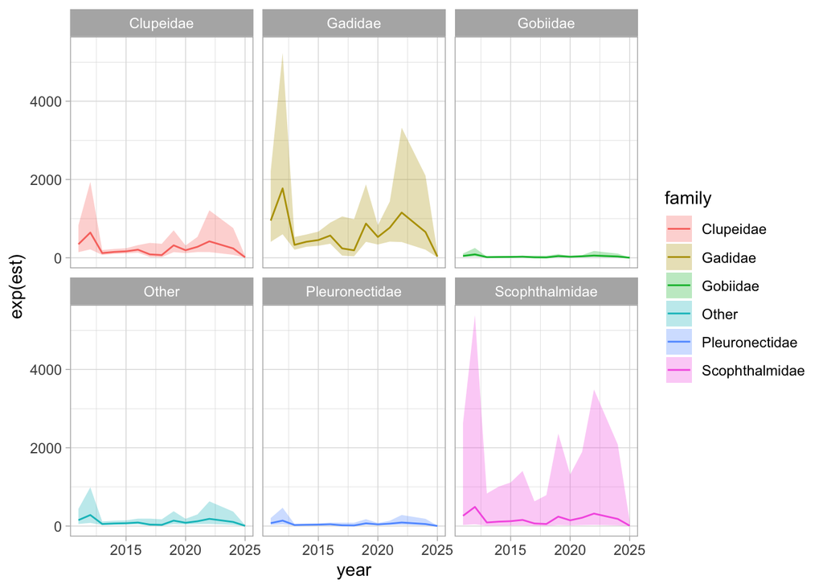

```r
# Now plot the year-prediction
p6 |>
  ggplot(aes(year, exp(est), color = family, fill = family)) +
  geom_line() +
  geom_ribbon(aes(ymin = exp(lwr), ymax = exp(upr)),
              alpha = 0.3, color = NA) +
  facet_wrap(~family)
```

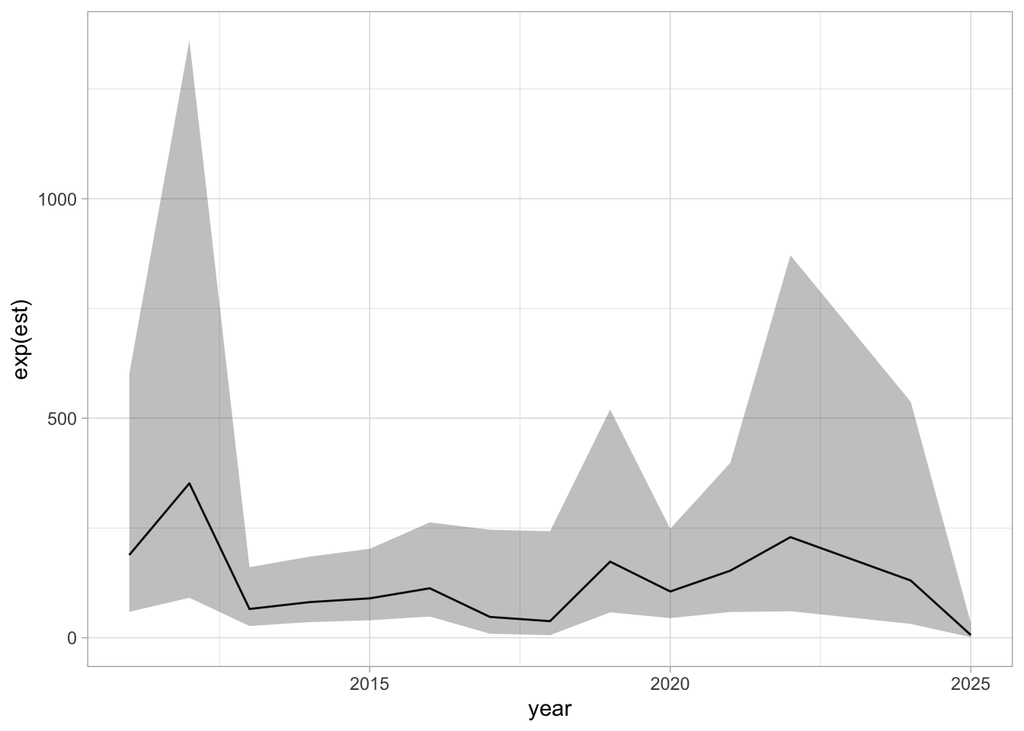

```r
# And now the total prey weight over time
p6 |>
  summarise(est = mean(est),
            upr = mean(upr),
            lwr = mean(lwr), .by = year) |>
  ggplot(aes(year, exp(est))) +
  geom_line() +
  geom_ribbon(aes(ymin = exp(lwr), ymax = exp(upr)),
              alpha = 0.3, color = NA)
```

```r
m7 <- sdmTMB(
  pw ~ 1 + family,
  data = d,
  time_varying = ~1,
  time_varying_type = "ar1",
  mesh = mesh,
  extra_time = 2023,
  time = "year",
  family = delta_gamma(type = "poisson-link"),
  spatial = list("on", "off"),
  spatiotemporal = "off"
)


# Plot spatial random effect?
nd7 <- d |>
  distinct(X, Y, lon, lat) |>
  mutate(year_f = as.factor("2011"),
         family = as.factor("Gadidae"))

p7 <- predict(m6, newdata = nd7, re_form_iid = NA)

p7
```

```
# A tibble: 195 × 13
       X     Y   lon   lat year_f family   est1  est2 est_non_rf1 est_non_rf2
   <dbl> <dbl> <dbl> <dbl> <fct>  <fct>   <dbl> <dbl>       <dbl>       <dbl>
 1  630. 6502.  11.2  58.6 2011   Gadidae 0.767  6.24       0.619        6.24
 2  637. 6461.  11.3  58.3 2011   Gadidae 0.646  6.24       0.619        6.24
 3  637. 6464.  11.3  58.3 2011   Gadidae 0.634  6.24       0.619        6.24
 4  630. 6501.  11.2  58.6 2011   Gadidae 0.750  6.24       0.619        6.24
 5  626. 6505.  11.2  58.7 2011   Gadidae 0.674  6.24       0.619        6.24
 6  672. 6384.  11.9  57.6 2011   Gadidae 0.607  6.24       0.619        6.24
 7  684. 6351.  12.0  57.3 2011   Gadidae 0.631  6.24       0.619        6.24
 8  647. 6454.  11.5  58.2 2011   Gadidae 0.661  6.24       0.619        6.24
 9  628. 6472.  11.2  58.4 2011   Gadidae 0.487  6.24       0.619        6.24
10  625. 6517.  11.2  58.8 2011   Gadidae 0.617  6.24       0.619        6.24
# ℹ 185 more rows
# ℹ 3 more variables: est_rf1 <dbl>, est_rf2 <dbl>, omega_s1 <dbl>
```

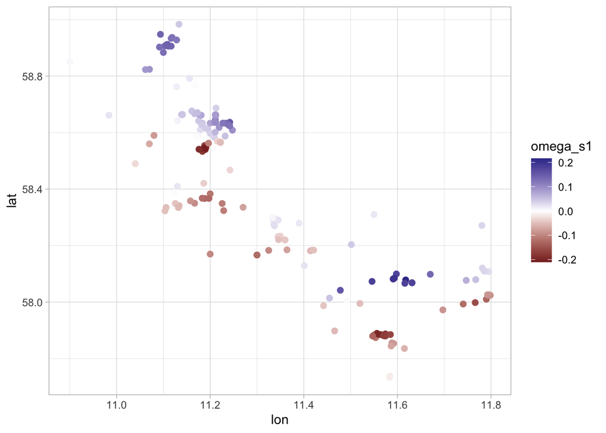

```r
p7 |>
  filter(lat > 57.7) |>
  ggplot(aes(lon, lat, color = omega_s1)) +
  geom_point(size = 2) +
  scale_color_gradient2()
```

```r
AIC(m1, m2, m3, m4, m5, m6, m7) |>
  arrange(AIC)
```

```
   df      AIC
m2 39 8199.383
m1 13 8200.808
m6 41 8201.165
m7 19 8202.983
m3 15 8203.117
m4 25 8206.474
m5 17 8206.497
```

Now, AIC says the model 2 is most parsimonious. It has a separate intercept for each year, and a separate intercept for each family.

I do think the AICs are not THAT far off. We definitely do not have to be so restrictive and dismiss spatial and/or ar1 models at this point, since they fit nicely. I also think it’s nice to model the mean prey weight as a ar1 process, because its’ more in line with how time series work (we do expect 2012 to be more similar to 2011). Also the clear spatial pattern in precense/absence warrants a deeper investigation.

A few things to follow up on:

1. Can we estimate a spatiotemporal random field? (different spatial predictions every year?)
2. Can we estimate spatial variability in prey types? One way to do that is to model family as an intercept (like we do), and spatial deviation on top off that with spatial_varying = ~0 + family? Then we would have spatial differences in predicted diets, which we can relate to trawl data
3. s(day, by = prey?)